# 326.212 Final Project: Part 3

## 2018-11120 양은주

```r
con = dbConnect(SQLite(), "project.sqlite")
```

## Part 3. Advanced Questions (100 pts)

Provide a graphical summary to answer the following questions. These are intentionally vague in order to allow you to focus on different aspects of the data. We only provide some suggestions.

### Q1. When is the best time of day/day of week/time of year to fly to minimise delays? (50 pts)

Suggestions: cancelled flights do not possess delays. You may want to ignore negative delays.

#### Distribution of scheduled departure time and delays

```r
delays.arrival = dplyr::tbl(con, "flights") %>%
  group_by(Arr_Delay) %>%
  summarise(n = n()) %>%
  collect()
```

```r
delays.departure = dplyr::tbl(con, "flights") %>%
  group_by(Dep_Delay) %>%
  summarise(n = n()) %>%
  collect()
```

```r
sched.dep.time = dplyr::tbl(con, "flights") %>%
  filter(Cancelled == 0) %>%
  group_by(CRS_Dep_Time) %>%
  summarise(n = n()) %>%
  mutate(sched_dep_time_m = ((CRS_Dep_Time %/% 100) %% 24)*60 + CRS_Dep_Time %% 100) %>%
  collect()
```

```r
plot1A = ggplot(data = sched.dep.time) +
  geom_bar(mapping = aes(x = sched_dep_time_m, y = n), stat = "identity", width = 1/2) +
  scale_y_log10(labels = trans_format("log10", math_format(10^.x))) +
  scale_x_continuous(breaks = seq(0, 1440, 120)) +
  labs(x = "Scheduled departure time (min)", y = "Number of flights") +
  theme(axis.title.y = element_text(size = 8))
```

```r
plot1B = ggplot(data = delays.arrival) +
  geom_bar(mapping = aes(x = Arr_Delay/60, y = n), stat = "identity", width = 1/120, fill = "purple") +
  scale_y_log10(labels = trans_format("log10", math_format(10^.x))) +
  coord_cartesian(xlim = c(-24, 48)) +
  scale_x_continuous(breaks = seq(-24, 48, 6)) +
  labs(x = "Arrival delays (hour)", y = "Number of flights") +
  theme(axis.title.y = element_text(size = 8))
```

```r
plot1C = ggplot(data = delays.departure) +
  geom_bar(mapping = aes(x = Dep_Delay/60, y = n), stat = "identity", width = 1/120, fill = "orange") +
  scale_y_log10(labels = trans_format("log10", math_format(10^.x))) +
  coord_cartesian(xlim = c(-24, 48)) +
  scale_x_continuous(breaks = seq(-24, 48, 6)) +
  labs(x = "Departure delays (hour)", y = "Number of flights") +
  theme(axis.title.y = element_text(size = 8))
```

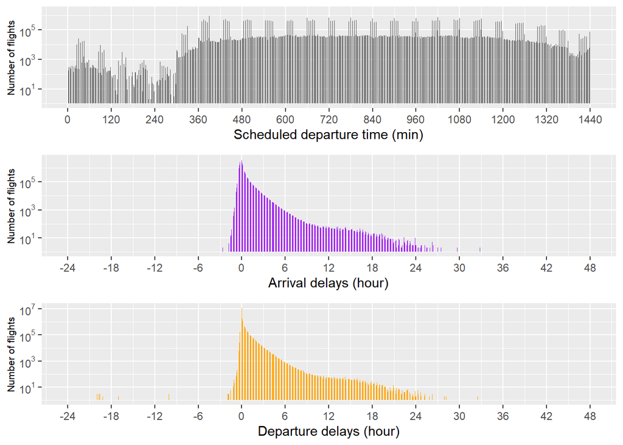

```r
grid.arrange(plot1A, plot1B, plot1C, nrow = 3, ncol = 1)
```

본격적인 분석에 들어가기에 앞서, 출발 예정 시각, 도착 지연 시간, 출발 지연 시간의 분포를 파악했다. 효과적인 시각화를 위해 로그 스케일의 플랏팅을 수행한 결과, 새벽 0시에서 5시 사이에 출발이 예정되어 있는 항공편은 매우 적었다. 도착 지연 시간과 출발 지연 시간의 경우 대부분이 0 근처에 몰려 있는 것과, 일찍 출발하는 경우가 일찍 도착하는 경우보다 희귀하다는 것을 관찰할 수 있었다.

#### The best time of day to fly to minimise delays

```r
delays.timely = dplyr::tbl(con, "flights") %>%
  filter(Cancelled == 0, !is.na(CRS_Dep_Time)) %>%
  select(CRS_Dep_Time, Arr_Delay, Dep_Delay) %>%
  mutate(sched_dep_time_h = (CRS_Dep_Time %/% 100) %% 24) %>%
  group_by(sched_dep_time_h) %>%
  summarise(arr_on_time = mean(Arr_Delay <= 0, na.rm = TRUE), avg_arr_delay = mean(Arr_Delay[Arr_Delay > 0], na.rm = TRUE),
            dep_on_time = mean(Dep_Delay <= 0, na.rm = TRUE), avg_dep_delay = mean(Dep_Delay[Dep_Delay > 0], na.rm = TRUE)) %>%
  collect()
```

```r
plot2A = ggplot(data = delays.timely, mapping = aes(x = sched_dep_time_h)) +
  geom_area(mapping = aes(y = (1 - arr_on_time)*100, alpha = 0.2), fill = "purple") +
  geom_line(mapping = aes(y = avg_arr_delay, colour = "purple")) +
  geom_point(mapping = aes(y = avg_arr_delay, colour = "purple")) +
  coord_cartesian(ylim = c(10, 60)) +
  scale_x_continuous(breaks = 0:23, minor_breaks = NULL) +
  scale_y_continuous(sec.axis = sec_axis(~., name = "")) +
  labs(x = "Scheduled departure time (hour)", y = "") +
  scale_alpha_identity(name = "", guide = "legend", labels = c("% of flights possess\narrival delays")) +
  scale_color_identity(name = "", breaks = c("purple"), guide = "legend", labels = c("Average arrival\ndelays (min)"))
```

```r
plot2B = ggplot(data = delays.timely, mapping = aes(x = sched_dep_time_h)) +
  geom_area(mapping = aes(y = (1 - dep_on_time)*100, alpha = 0.2), fill = "orange") +
  geom_line(mapping = aes(y = avg_dep_delay, colour = "orange")) +
  geom_point(mapping = aes(y = avg_dep_delay, colour = "orange")) +
  coord_cartesian(ylim = c(10, 60)) +
  scale_x_continuous(breaks = 0:23, minor_breaks = NULL) +
  scale_y_continuous(sec.axis = sec_axis(~., name = "")) +
  labs(x = "Scheduled departure time (hour)", y = "") +
  scale_alpha_identity(name = "", guide = "legend", labels = c("% of flights possess\ndeparture delays")) +
  scale_color_identity(name = "", breaks = c("orange"), guide = "legend", labels = c("Average departure\ndelays (min)"))
```

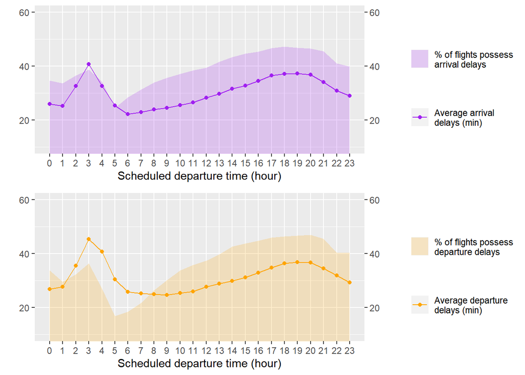

```r
grid.arrange(plot2A, plot2B, nrow = 2, ncol = 1)
```

하루 중 지연을 최소로 할 수 있는 항공편의 출발 시간대를 찾기 위해, DB의 `flights` table에서 출발 예정 시각별 평균 지연 시간과 지연된 항공편 비율을 집계하여 `delays.timely` table에 저장했다. `delays.timely`에 대한 플랏팅 결과, 6시에서 8시 사이에 평균 지연 시간이 가장 작게 나타났다. 시간이 지날수록 평균 지연 시간과 지연된 항공편의 비율은 완만하게 증가하다 18시에서 20시 사이에 정점에 달했다. 따라서 아침에 출발하는 경우는 최대한 빨리 출발하고, 저녁에 출발하는 경우는 20시가 지난 늦은 밤이나 1시 이전의 이른 새벽에 출발하면 작은 지연 시간을 기대할 수 있다는 결론을 얻었다.

```r
delays.daily.timely = dplyr::tbl(con, "flights") %>%
  filter(Cancelled == 0, !is.na(CRS_Dep_Time), Arr_Delay > 0, Dep_Delay > 0) %>%
  mutate(sched_dep_time_h = (CRS_Dep_Time %/% 100) %% 24) %>%
  group_by(Year, Month, Day_of_Month, sched_dep_time_h) %>%
  summarise(avg_arr_delay = mean(Arr_Delay, na.rm = TRUE),
            avg_dep_delay = mean(Dep_Delay, na.rm = TRUE)) %>%
  collect()
```

```r
delays.daily.timely = delays.daily.timely %>%
  gather(avg_arr_delay, avg_dep_delay, key = "type", value = "avg_delay")
```

```r
quantile(delays.daily.timely$avg_delay, probs = 0.9)
```

```
##     90%
## 55.0953
```

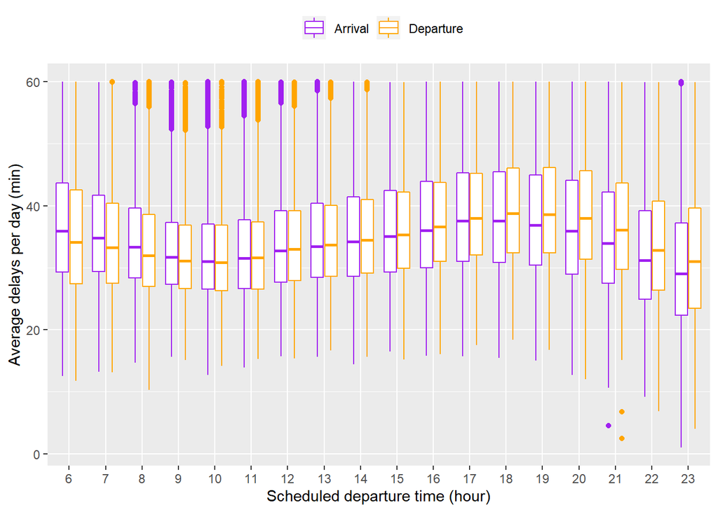

```r
ggplot(data = delays.daily.timely %>% filter(sched_dep_time_h > 5, avg_delay < 60)) +
  geom_boxplot(mapping = aes(x =as_factor(sched_dep_time_h), y = avg_delay, colour = type)) +
  labs(x = "Scheduled departure time (hour)", y = "Average delays per day (min)") +
  scale_color_manual(values = c("purple", "orange"), label = c("Arrival", "Departure"), name = "") +
  theme(legend.position = "top")
```

#### The best day of week to fly to minimise delays

```r
delays.daily = dplyr::tbl(con, "flights") %>%
  filter(Cancelled == 0) %>%
  group_by(Year, Month, Day_of_Month) %>%
  summarise(arr_on_time = mean(Arr_Delay <= 0, na.rm = TRUE),
            avg_arr_delay = mean(Arr_Delay[Arr_Delay > 0], na.rm = TRUE),
            dep_on_time = mean(Dep_Delay <= 0, na.rm = TRUE),
            avg_dep_delay = mean(Dep_Delay[Dep_Delay > 0], na.rm = TRUE)) %>%
  collect()
```

```r
delays.daily = delays.daily %>%
  filter(!is.na(avg_arr_delay), !is.na(avg_dep_delay)) %>%
  mutate(Date = make_date(Year, Month, Day_of_Month), DoW = wday(Date, label = TRUE)) %>%
  select(Date, DoW, arr_on_time, dep_on_time, avg_arr_delay, avg_dep_delay)
```

```r
plot3A = ggplot(data = delays.daily) +
  geom_boxplot(mapping = aes(x = reorder(DoW, (1 - arr_on_time)*100, FUN = median), y = (1 - arr_on_time)*100), fill = "purple", alpha = 0.2) +
  labs(x = "", y = "% of flights possess\narrival delays")
```

```r
plot3B = ggplot(data = delays.daily) +
  geom_boxplot(mapping = aes(x = reorder(DoW, avg_arr_delay, FUN = median), y = avg_arr_delay), fill = "purple", alpha = 0.2) +
  labs(x = "", y = "Average arrival\ndelays per day (min)")
```

```r
plot3C = ggplot(data = delays.daily) +
  geom_boxplot(mapping = aes(x = reorder(DoW, (1 - dep_on_time)*100, FUN = median), y = (1 - dep_on_time)*100), fill = "orange", alpha = 0.2) +
  labs(x = "", y = "% of flights possess\ndeparture delays")
```

```r
plot3D = ggplot(data = delays.daily) +
  geom_boxplot(mapping = aes(x = reorder(DoW, avg_dep_delay, FUN = median), y = avg_dep_delay), fill = "orange", alpha = 0.2) +
  labs(x = "", y = "Average departure\ndelays per day (min)")
```

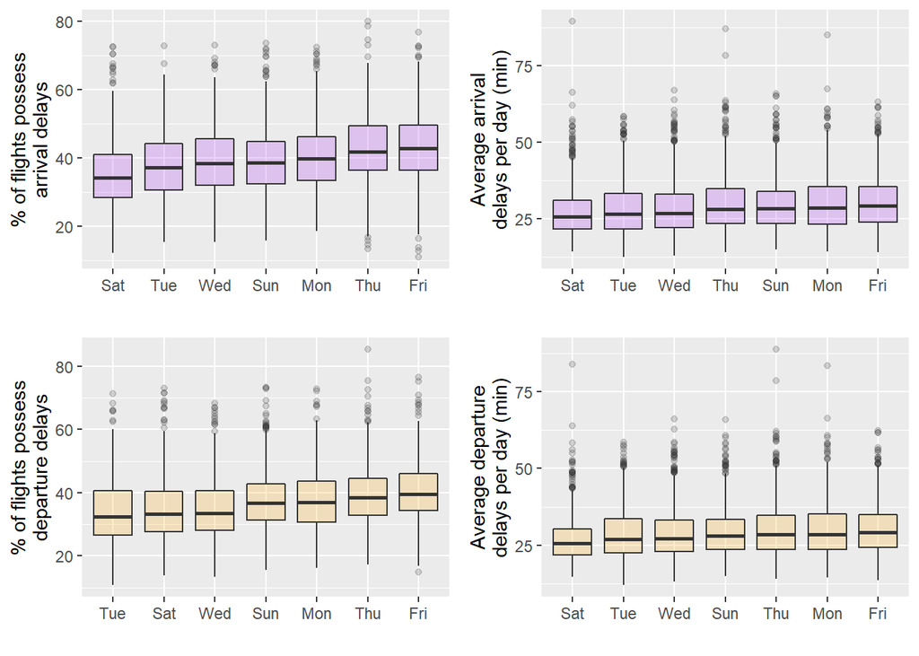

```r
grid.arrange(plot3A, plot3B, plot3C, plot3D, nrow = 2, ncol = 2)
```

일주일 중 지연을 최소로 할 수 있는 요일을 알아내기 위해, DB의 `flights` table에서 일별 평균 지연 시간, 지연된 항공편의 비율을 집계하여 `delays.daily` table에 저장했다. 이에 `geom_boxplot()`과 `reorder`를 적용하여 요일별 플랏팅을 수행한 결과 토요일에 일별 평균 지연 시간 뿐만 아니라 도착이 지연된 항공편 비율에 대한 중간값과 IQR이 가장 작음을 확인할 수 있었다. 전반적으로 지연이 심한 요일은 금요일이었던 반면, 화요일과 수요일은 준수했다. 지연 시간이 작기를 바란다면 토요일, 화요일, 수요일에 출발하되 금요일은 피해야 한다.

#### The best time of year to fly to minimise delays

```r
volume.origin.dest = dplyr::tbl(con, "flights") %>%
  filter(Cancelled == 0) %>%
  group_by(Origin, Dest) %>%
  summarise(n = n()) %>%
  arrange(desc(n)) %>%
  collect()
```

```r
airports = dplyr::tbl(con, "airports") %>%
  collect()
```

```r
volume.origin.dest = left_join(volume.origin.dest, airports, by = c("Origin" = "IATA")) %>%
  select(Origin, Dest, n, Origin_Lat = Latitude, Origin_Long = Longitude) %>%
  left_join(airports, by = c("Dest" = "IATA")) %>%
  select(Origin, Dest, n, Origin_Lat, Origin_Long, Dest_Lat = Latitude, Dest_Long = Longitude)
```

```r
volume.origin = volume.origin.dest %>%
  group_by(Origin) %>%
  summarise(n = sum(n)) %>%
  arrange(desc(n))
```

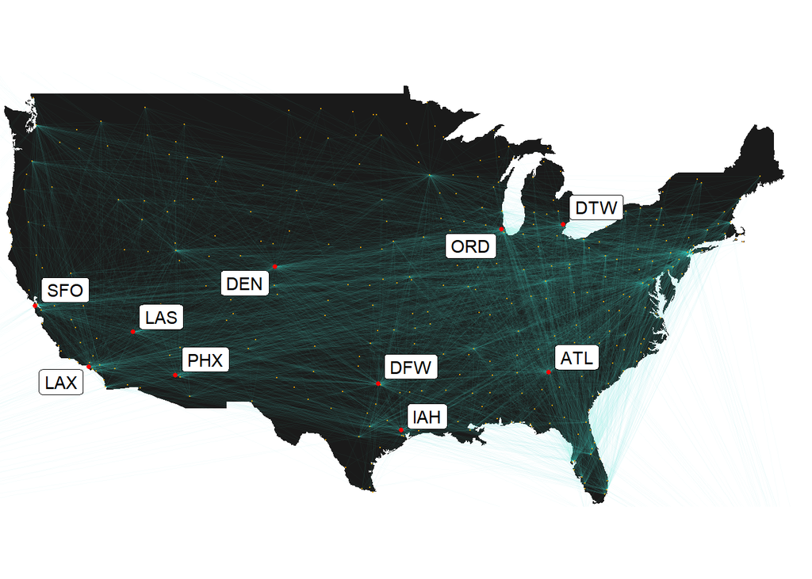

```r
ggplot(data = map_data("usa")) +
  geom_polygon(mapping = aes(x = long, y = lat, group = group), fill = "gray10") +
  geom_segment(data = volume.origin.dest,
               mapping = aes(x = Origin_Long, y = Origin_Lat, xend = Dest_Long, yend = Dest_Lat),
               alpha = 1/40, colour = "turquoise", size = 0.1) +
  geom_point(data = volume.origin.dest,
             mapping = aes(x = Origin_Long, y = Origin_Lat), colour = "orange", size = 0.1) +
  geom_point(data = tibble(IATA = head(volume.origin, 10)$Origin) %>% left_join(airports, by = "IATA"),
             mapping = aes(x = Longitude, y = Latitude), colour = "red", size = 1) +
  geom_label_repel(data = tibble(IATA = head(volume.origin, 10)$Origin) %>% left_join(airports, by = "IATA"),
                   mapping = aes(x = Longitude, y = Latitude, label = IATA)) +
  coord_map(xlim = c(-125, -65), ylim = c(25, 50)) +
  theme_void()
```

편의상 비행기가 자주 떠나는 출발지들을 추려서 분석을 진행했다. 우선 DB의 `flights` table에서 각각의 출발지와 목적지에 해당하는 항공편의 수를 집계하여 `volume.origin.dest`에 저장한 뒤 `map_data()`를 사용하여 실제 위치에 맞게 공항들과 노선들을 시각화했다. 비행기가 자주 떠나는 상위 10개의 출발지들은 `geom_label_repel`을 적용하여 이름을 붙였다.

```r
head(x = volume.origin %>% left_join(airports, by = c("Origin" = "IATA")) %>% select(Origin, Name, n), n = 4)
```

```
## # A tibble: 4 x 3
##   Origin Name                                                   n
##   <chr>  <chr>                                              <int>
## 1 ATL    Hartsfield Jackson Atlanta International Airport 6744933
## 2 ORD    Chicago O'Hare International Airport             5674808
## 3 DFW    Dallas Fort Worth International Airport          4901453
## 4 LAX    Los Angeles International Airport                3866549
```

비행기가 가장 많이 떠나는 출발지들은 ATL(Hartsfield Jackson Atlanta International Airport), ORD(Chicago O’Hare International Airport), DRW(Dallas Fort Worth International Airport), LAX(Los Angeles International Airport)인 것으로 확인되었다. 이에 따라 이하 분석은 출발지가 ATL, ORD, DFW, LAX 중 하나에 해당하는 항공편에 한정했다.

```r
delays.monthly = dplyr::tbl(con, "flights") %>%
  filter(Cancelled == 0, Origin %in% c("ATL", "ORD", "DFW", "LAX")) %>%
  group_by(Year, Month, Origin) %>%
  summarise(avg_arr_delay = mean(Arr_Delay[Arr_Delay > 0], na.rm = TRUE),
            avg_dep_delay = mean(Dep_Delay[Dep_Delay > 0], na.rm = TRUE)) %>%
  collect()
```

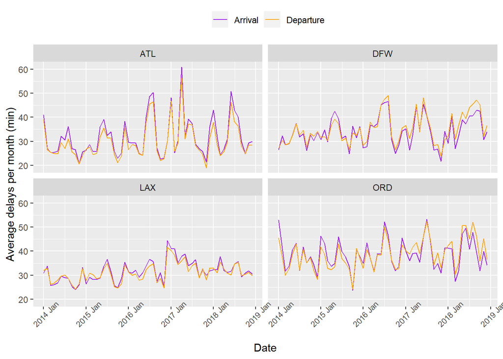

```r
ggplot(data = filter(delays.monthly, Year > 2013)) +
  geom_line(mapping = aes(x = make_date(Year, Month, 1), y = avg_arr_delay, colour = "purple")) +
  geom_line(mapping = aes(x = make_date(Year, Month, 1), y = avg_dep_delay, colour = "orange")) +
  scale_x_date(date_labels = "%Y %b", date_breaks = "1 years") +
  theme(axis.text.x = element_text(angle = 45, size = 8)) +
  labs(x = "Date", y = "Average delays per month (min)") +
  facet_wrap(~ Origin) +
  scale_color_identity(name = "", breaks = c("purple", "orange"), labels = c("Arrival", "Departure"), guide = "legend") +
  theme(legend.position = "top")
```

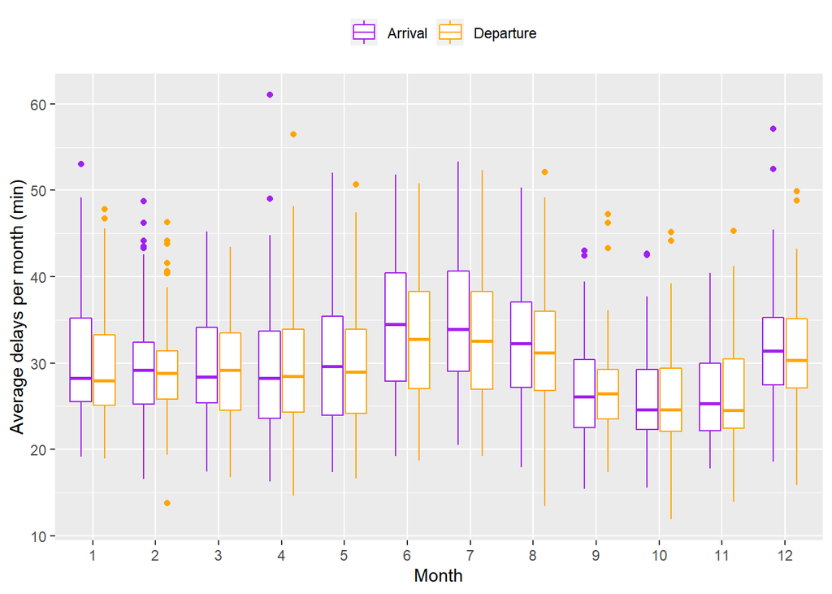

```r
ggplot(data = delays.monthly %>% gather(avg_arr_delay, avg_dep_delay, key = "type", value = "avg_delay")) +
  geom_boxplot(mapping = aes(x = factor(Month), y = avg_delay, colour = type)) +
  scale_color_manual(values = c("purple", "orange"), label = c("Arrival", "Departure"), name = "") +
  labs(x = "Month", y = "Average delays per month (min)") +
  theme(legend.position = "top")
```

`geom_boxplot()`을 이용하여 달마다 월별 평균 지연 시간을 시각화한 결과 예상한 바와 같이 6, 7, 8월에 중간값과 IQR이 큰 것을 확인할 수 있었다. 9, 10, 11월은 중간값과 IQR이 뚜렷하게 작았지만, 위의 플랏에서 관찰한 바와 같이 12월 전후에 IQR이 크게 상승하지는 않았다. 따라서 여름을 6 ~ 8월, 가을을 9 ~ 11월, 나머지를 겨울에서 봄으로 정의하면 평균 지연 시간은 계절성을 가진다는 해석을 할 수 있다.

### Q2. Do older planes suffer more delays? (50 pts)

Suggestions: you may want to find a correlation between the age of the plane and the departure delay. If the data size is too big to compute the correlation, you may try to sample a fraction from the dataset.

```r
airplanes = dplyr::tbl(con, "airplanes") %>%
  collect()
```

```r
planes.age = dplyr::tbl(con, "flights") %>%
  filter(Cancelled == 0) %>%
  select(Year, Month, Day_of_Month, CRS_Dep_Time, Tail_Num, Dep_Delay) %>%
  arrange(Dep_Delay) %>%
  filter(row_number() %% 100 == 0) %>%
  select(Year, Month, CRS_Dep_Time, Tail_Num, Dep_Delay) %>%
  collect()
```

```r
term = function(month){
  if(month %in% c(6, 7, 8)){return("summer")}
  else if(month %in% c(9, 10, 11)){return("fall")}
  else{return("winter_to_spring")}
}
```

```r
planes.age = planes.age %>%
  left_join(filter(airplanes, !is.na(Year), Year != "None", Year != 0), by = c("Tail_Num" ="TailNum")) %>%
  mutate(Term = map_chr(Month, term),
         Dep_Time = (as.integer(CRS_Dep_Time) %/% 100) %% 24,
         Plane_Age = as.integer(Year.x) - as.integer(Year.y)) %>%
  select(Term, Dep_Time, Plane_Age, Dep_Delay) %>%
  filter(Plane_Age >= 0, Dep_Time >= 5)
```

```r
mod = lm(Dep_Delay ~ ns(Dep_Time, 3) + Term, data = planes.age)
```

```r
plot4A = ggplot(data = planes.age %>% filter(Dep_Delay > 0)) +
  geom_hex(mapping = aes(x = Plane_Age, y = Dep_Delay)) +
  scale_fill_viridis_c(trans = "log10", name = "Number of flights") +
  scale_x_continuous(breaks = seq(0, 61, 5)) +
  scale_y_continuous(breaks = seq(0, 1800, 200)) +
  coord_cartesian(ylim = c(0, 1800)) +
  labs(x = "Plane age (year)", y = "Departure delays (min)", caption = "1/100 systematic sampling") +
  theme(legend.position = "top")
```

```r
planes.age = add_residuals(mod, data = planes.age)
```

```r
plot4B = ggplot(data = planes.age %>% filter(Dep_Delay > 0)) +
  geom_hex(mapping = aes(x = Plane_Age, y = resid)) +
  scale_fill_viridis_c(trans = "log10", name = "Number of flights") +
  scale_x_continuous(breaks = seq(0, 61, 5)) +
  scale_y_continuous(breaks = seq(0, 1800, 200)) +
  coord_cartesian(ylim = c(0, 1800)) +
  labs(x = "Plane age (year)", y = "Residuals of departure delays (min)", caption = "1/100 systematic sampling") +
  theme(legend.position = "top")
```

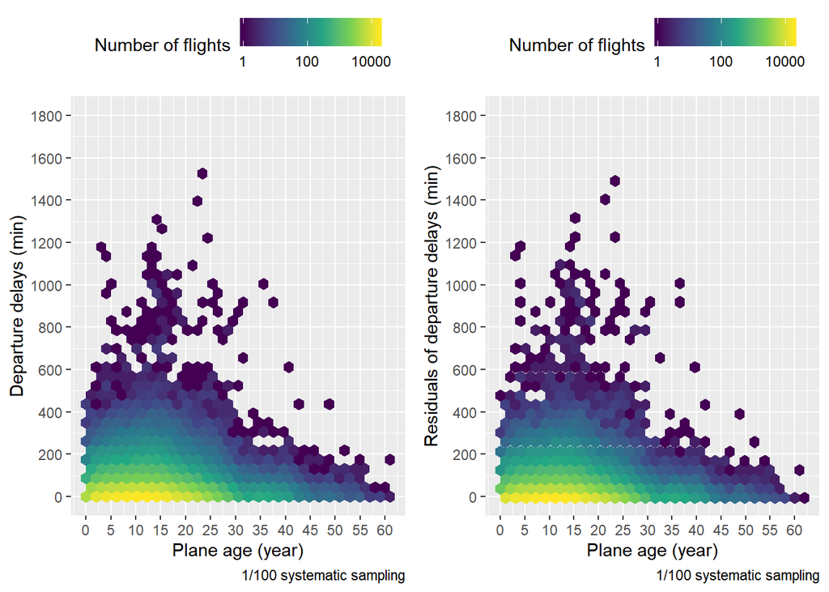

```r
grid.arrange(plot4A, plot4B, nrow = 1)
```

항공기의 연식과 출발 지연 시간에 대한 상관관계를 분석하기 전에 용량 제한 문제를 해결하기 위해서 DB의 `flights` table을 출발 지연 시간 순으로 정렬한 다음 $\frac{1}{100}$ 계통추출을 한 뒤 0시에서 5시 사이에 출발이 예정된 항공편은 제외하여 `planes.age`라는 샘플을 얻었다(0시에서 5시 사이에 출발이 예정된 항공편은 극히 적음을 1번 문제에서 확인했음). Ordered population에서는 계통추출을 통해 생성한 추정량이 단순임의추출을 통해 생성한 추정량에 비해 분산이 작다는 사실이 알려져 있기에 이와 같은 방법을 사용한 것이다. 앞선 분석에서 항공기의 출발 지연 시간은 출발 예정 시각, 요일, 계절에 영향을 받는다는 것을 확인했다. 따라서 상관관계를 정확하게 파악하기 위해서는 출발 예정 시각, 요일, 계절에 의한 영향을 제거해야 한다. 요일의 영향은 상대적으로 미미하기 때문에 나머지 두 변수를 통해 출발 지연 시간을 설명하는 model인 `mod`를 생성했다. 계절은 범주형 변수이지만, 출발 예정 시각은 연속형 변수이다. 1번 문제에서 출발 예정 시각에 따른 출발 지연 시간은 10시와 20시에 극점을 찍기 때문에 단순한 `lm`이 아니라 `splines::ns()`를 적용했다. 항공기의 연식과 출발 지연 시간에 대한 일반적인 플랏과 출발 예정 시각, 계절에 의한 영향을 제거한 플랏을 생성한 결과 두 경우 전부 지연 시간이 0 부근인 라인에서 항공기 연식 15년을 전후하여 색이 변하는 양상이 뒤집힘을 관찰할 수 있었다(항공편의 수가 증가했다 다시 줄어듦).

```r
quantile(planes.age$Plane_Age, probs = 0.90)
```

```
## 90%
##  21
```

```r
planes.age.1 = planes.age %>%
  filter(Plane_Age < 15) %>%
  group_by(Plane_Age) %>%
  summarise(n = n(), avg_dep_delay = mean(resid[resid > 0], na.rm = TRUE))
```

```r
planes.age.2 = planes.age %>%
  filter(Plane_Age > 14, Plane_Age < 22) %>%
  group_by(Plane_Age) %>%
  summarise(n = n(), avg_dep_delay = mean(resid[resid > 0], na.rm = TRUE))
```

```r
mod.1 = lm(avg_dep_delay ~ Plane_Age, data = planes.age.1, weights = n)
```

```r
mod.2 = lm(avg_dep_delay ~ Plane_Age, data = planes.age.2, weights = n)
```

```r
grid.1 = planes.age.1 %>%
  data_grid(Plane_Age) %>%
  add_predictions(mod.1)
```

```r
grid.2 = planes.age.2 %>%
  data_grid(Plane_Age) %>%
  add_predictions(mod.2)
```

```r
plot4C = ggplot(data = planes.age.1) +
  geom_point(mapping = aes(x = Plane_Age, y = avg_dep_delay, size = `n`), colour = "orange") +
  geom_line(data = grid.1, mapping = aes(x = Plane_Age, y = pred)) +
  scale_x_continuous(breaks = seq(0, 14, 1)) +
  scale_size_continuous(name = "Number of flights") +
  coord_cartesian(ylim = c(32, 41)) +
  annotate("text", x = 7, y = 40, label = expression(paste(R^{2}, " = 0.934507"))) +
  labs(x = "Plane age (year)", y = "Residuals of average\ndeparture delays (min)", caption = "1/100 systematic sampling")
```

```r
plot4D = ggplot(data = planes.age.2) +
  geom_point(mapping = aes(x = Plane_Age, y = avg_dep_delay, size = `n`), colour = "orange") +
  geom_line(data = grid.2, mapping = aes(x = Plane_Age, y = pred)) +
  scale_x_continuous(breaks = seq(15, 24, 1)) +
  scale_size_continuous(name = "Number of flights") +
  coord_cartesian(ylim = c(34, 41)) +
  annotate("text", x = 18, y = 40, label = expression(paste(R^{2}, " = 0.9917637"))) +
  labs(x = "Plane age (year)", y = "Residuals of average\ndeparture delays (min)", caption = "1/100 systematic sampling")
```

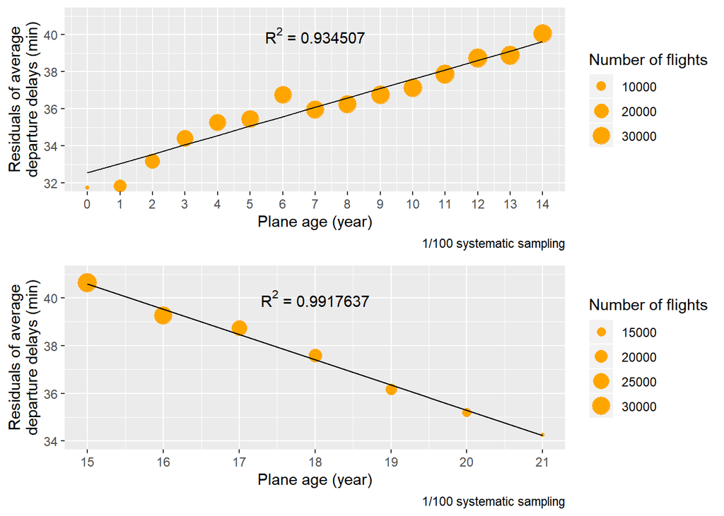

```r
grid.arrange(plot4C, plot4D, nrow = 2)
```

90%의 항공기가 연식이 21년 이하이기 때문에 연식이 21년 이하인 항공기에 대해서 연식 15년을 기준으로 `planes.age`을 `planes.age.1`과 `planes.age.2`로 분리한 다음 각각에 대해 가중 선형 회귀분석을 수행했다(가중치는 항공편의 수). 연식이 15년 미만인 항공기들에 대해서는 연식과 출발 지연 시간에 강한 양의 선형 관계가 있었다. 반면 연식이 15년 이상인 항공기들에 대해서는 연식과 출발 지연 시간에 강한 음의 선형 관계가 있었다. 이와 같은 결과가 나타난 한 가지 가능한 이유는 항공기가 운항을 시작한 이후에 결함들이 쌓이면서 출발 지연 시간이 늘어나다가 중간에 정비를 받아서 다시 줄어들기 때문일 것으로 추측된다.

```r
dbDisconnect(con)
```